# Loans Exploration by Mengqi Ye

## Loan Data from Prosper

This [data](https://s3.amazonaws.com/udacity-hosted-downloads/ud651/prosperLoanData.csv) set contains 113,937 loans with 81 variables on each loan, including loan amount, borrower rate (or interest rate), current loan status, borrower income, borrower employment status, borrower credit history, and the latest payment information.

## Load Data

It takes a while to load data, for a total of 113937 records with 81 variables.

## Data Wrangling

Ratings are reorganized so, that the grades are ordered from AA (low risk) to HR (high risk). The levels of `LoanStatus` are also reorganized so that the order is more meaningful (but still subjective) for further analyses. The variables `IncomeVerifiable`, `IsBorrowerHomeowner` and `CurrentlyInGroup` are converted to a logical variables.

BorrowerState : Most loans in CA, least in ND.

```r
sort(table(loans$BorrowerState))
```

```
##
##    ND    ME    WY    IA    SD    AK    VT    DE    MT    DC    WV    HI
##    52   101   150   186   189   200   207   300   330   382   391   409
##    RI    NM    NH    ID    NE    MS    AR    UT    LA    OK    KY    KS
##   435   472   551   599   674   787   855   877   954   971   983  1062
##    NV    SC    CT    AL    TN    OR    WI    AZ    IN    CO    MA    MN
##  1090  1122  1627  1679  1737  1817  1842  1901  2078  2210  2242  2318
##    MO    MD    PA    WA    NC    NJ    VA    MI    OH    GA          IL
##  2615  2821  2972  3048  3084  3097  3278  3593  4197  5008  5515  5921
##    FL    NY    TX    CA
##  6720  6729  6842 14717
```

## APR

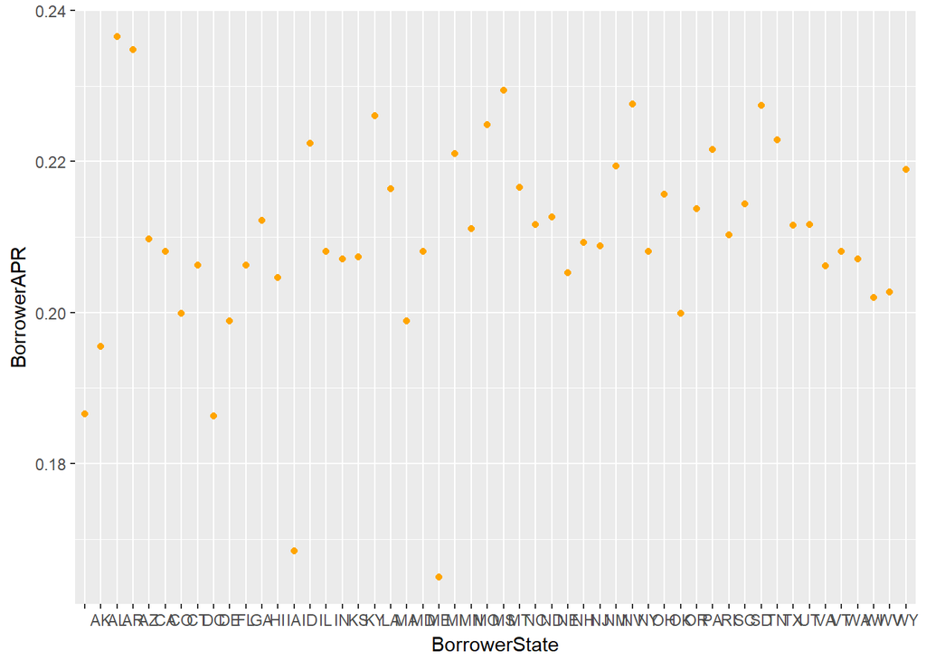

```r
ggplot(data = loans, aes(x=BorrowerState , y=BorrowerAPR)) +
  geom_point(stat="summary",
             fun.y="median",
             color="orange")
```

### APR by ListingCategory

0 - Not Available, 1 - Debt Consolidation, 2 - Home Improvement, 3 - Business, 4 - Personal Loan, 5 - Student Use, 6 - Auto, 7- Other, 8 - Baby&Adoption, 9 - Boat, 10 - Cosmetic Procedure, 11 - Engagement Ring, 12 - Green Loans, 13 - Household Expenses, 14 - Large Purchases, 15 - Medical/Dental, 16 - Motorcycle, 17 - RV, 18 - Taxes, 19 - Vacation, 20 - Wedding Loans APR is high for 10 - Cosmetic Procedure - 0.275 APR is lowest for 4 - Personal Loan

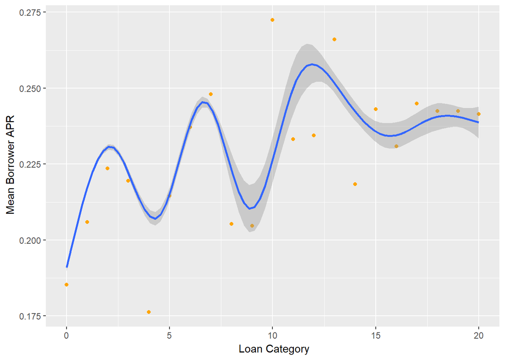

### APR by Employement duration

Usually, those who just got in field of employments, are more likely to apply for a loan. And they have a variety of APR. So there is no obvious correlation between APR and Employement duration. But if you think on the horizontal line gradient, it reflects on how people pay off their debts. And there are some faint points suggest that some worked for over 60 years, still haven’t pay off loans, makes you wonder how much they borrowed in the first place.

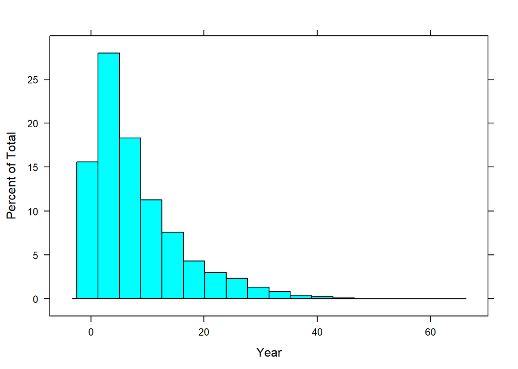

```r
loans$EmploymentStatusDurationInYears <- loans$EmploymentStatusDuration / 12
histogram(loans$EmploymentStatusDurationInYears,
          xlab="Year")
```

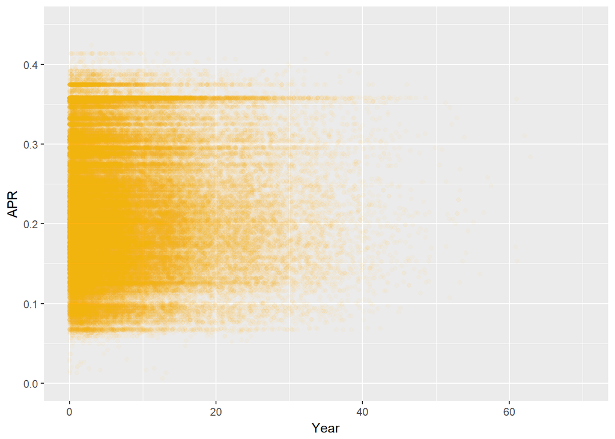

```r
ggplot(aes(x = EmploymentStatusDurationInYears, y = BorrowerAPR), data = loans)+
  geom_point(alpha=1/30, color="orange")+
  xlim(0,70)+ylim(0,0.45)+
  xlab("Year")+ylab("APR")
```

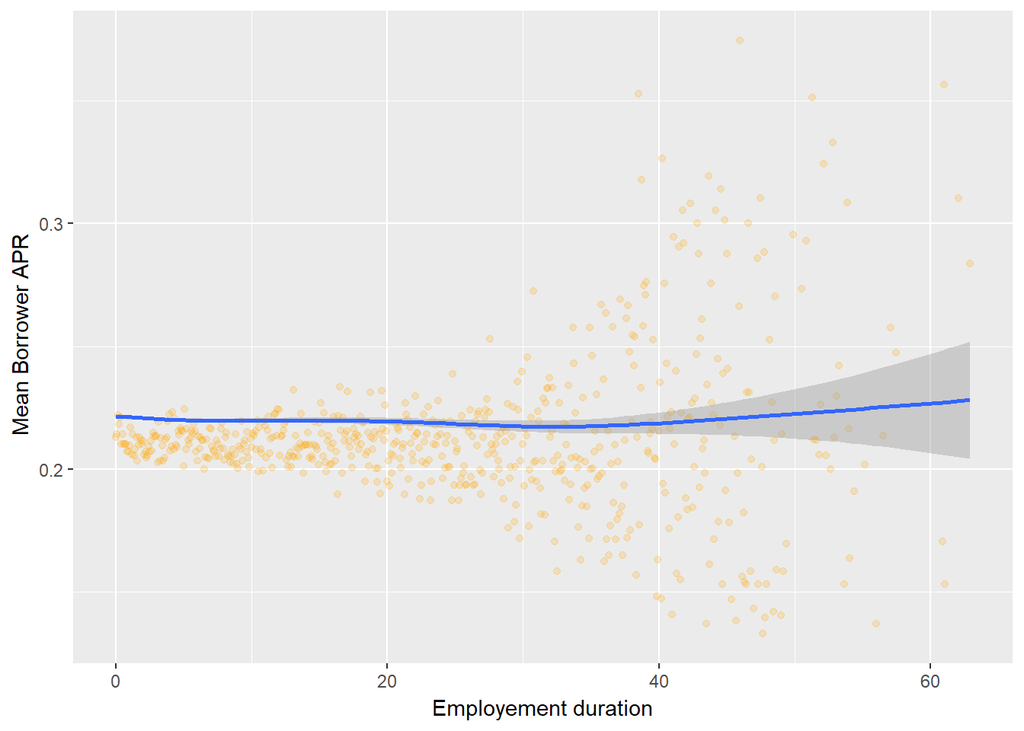

```r
ggplot(data = loans, aes(x= loans$EmploymentStatusDurationInYears, y=BorrowerAPR)) +
  geom_point(stat="summary",
             fun.y="median",
             alpha=1/5,
             color="orange") +
  ylab(" Mean Borrower APR") + xlab ("Employement duration") +
  geom_smooth()
```

### APR by IncomeRange

There is no surprise that people borrow money base on their income. And the highest APR fall on unemployed people.

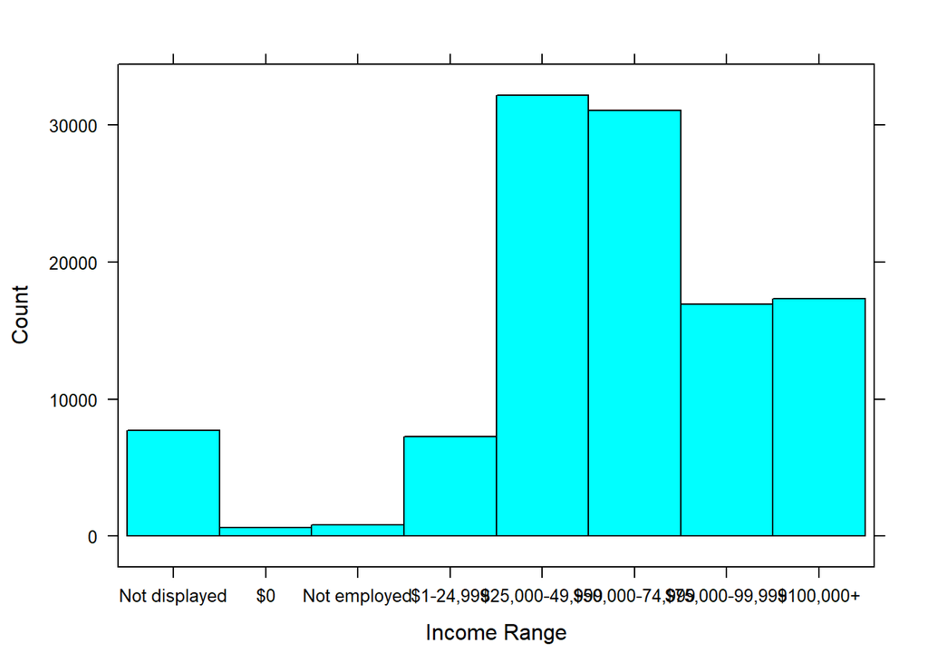

```r
loans$IncomeRange <- factor(loans$IncomeRange,
                            levels = c("Not displayed","$0","Not employed",
                                       "$1-24,999","$25,000-49,999",
                                       "$50,000-74,999","$75,000-99,999",
                                       "$100,000+") )

histogram(loans$IncomeRange,
          type="count",
          xlab="Income Range",
          )
```

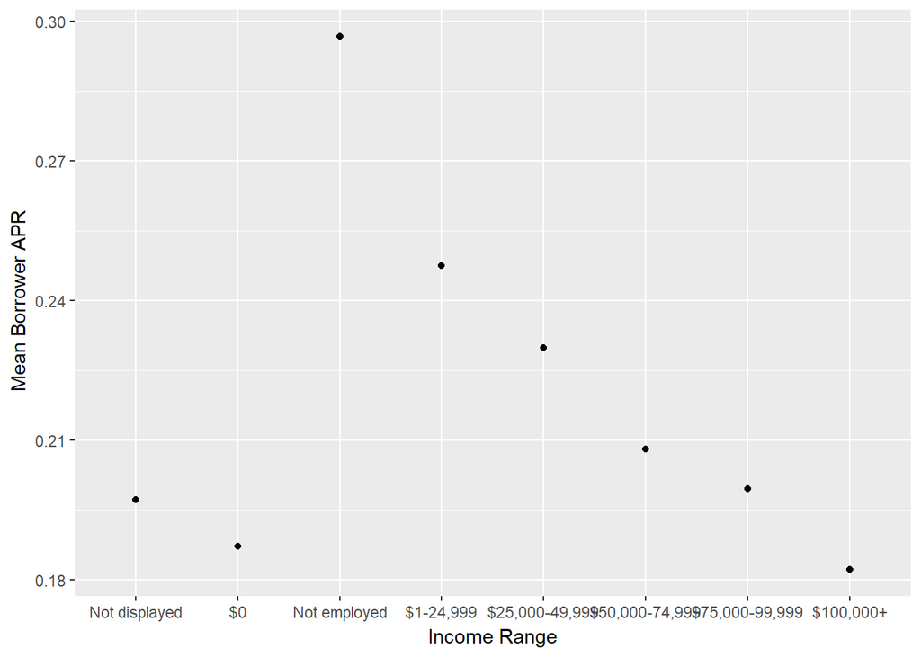

```r
ggplot(data = loans, aes(x= loans$IncomeRange, y=BorrowerAPR)) +
  geom_point(stat="summary", fun.y="median") +
  ylab(" Mean Borrower APR") + xlab ("Income Range")
```

### APR by ProsperScore

It only makes sense that higher prosper score leads to lower APR.

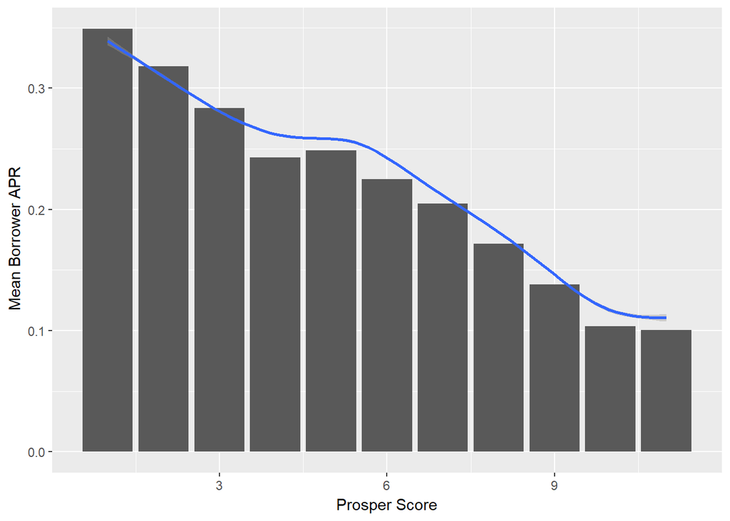

```r
ggplot(data = loans, aes(x= loans$ProsperScore, y=BorrowerAPR)) +
  geom_histogram(stat="summary", fun.y="median") +
  ylab(" Mean Borrower APR") + xlab ("Prosper Score") +
  geom_smooth()
```

#### APR by AmountDelinquent

Some people manage to have a low APR even though they’re deeply in debts, however, generally speaking, those who never have delinquent behaviours enjoys a lower APR.

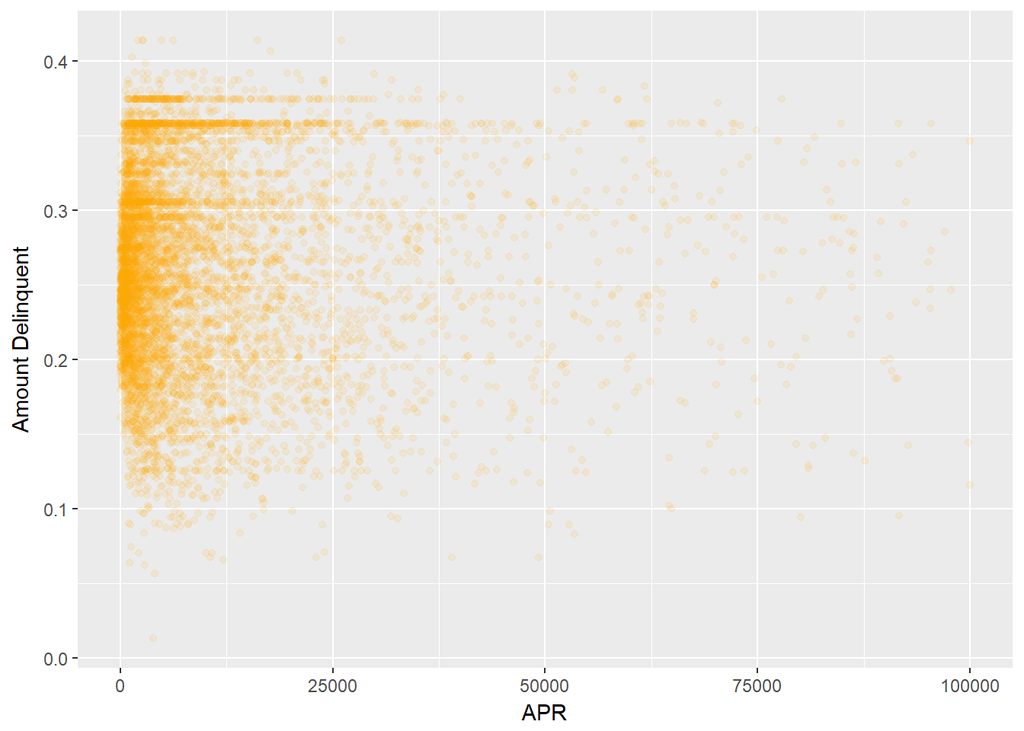

```r
loans$AmountDelinquent_BOOL <- loans$AmountDelinquent >0

ggplot(data = loans[loans$AmountDelinquent>1 & loans$AmountDelinquent< 100000,], aes(x= AmountDelinquent, y=BorrowerAPR)) +
  geom_point(stat="summary", fun.y="median",
             color="orange",alpha=0.1) +
  ylab("Amount Delinquent") + xlab ("APR")
```

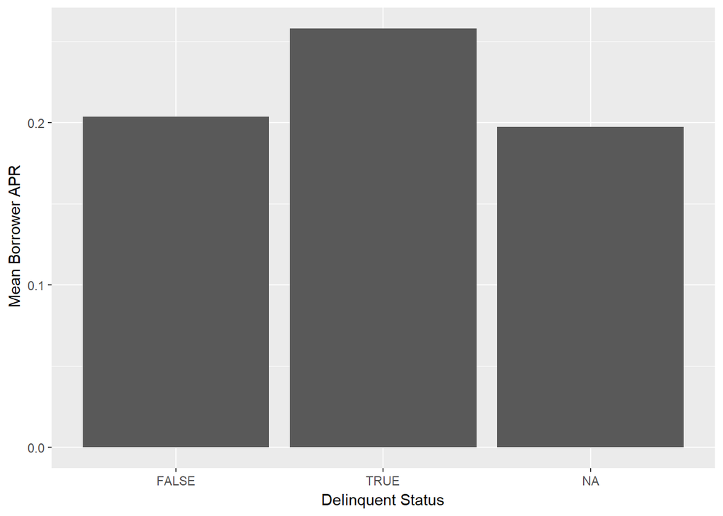

```r
ggplot(data = loans, aes(x= AmountDelinquent_BOOL, y=BorrowerAPR)) +
  geom_histogram(stat="summary", fun.y="median") +
  ylab(" Mean Borrower APR") + xlab ("Delinquent Status")
```

## Final Plots

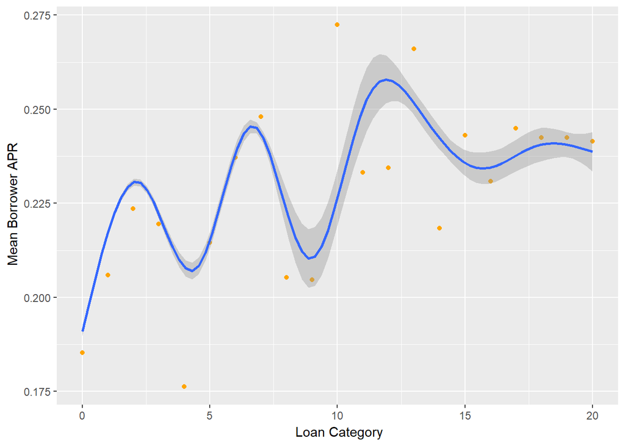

```r
ggplot(data = loans,
       aes(x = loans$ListingCategory, y = BorrowerAPR)) +
  geom_point(
    stat = "summary",
    fun.y = "median",
    color="orange"
    ) +
  ylab(" Mean Borrower APR") +
  xlab (" Loan Category") +
  geom_smooth()
```

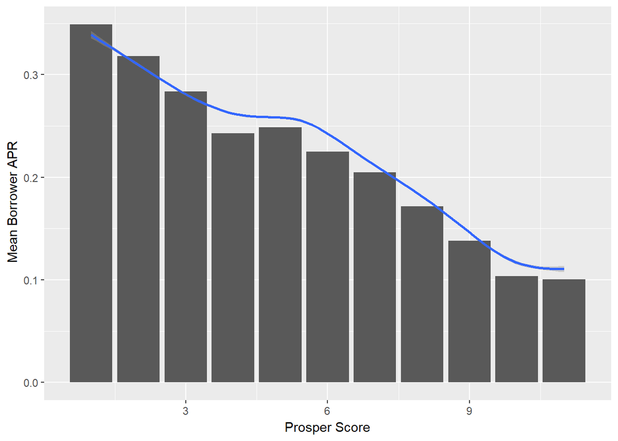

```r
ggplot(data = loans, aes(x= loans$ProsperScore, y=BorrowerAPR)) +
  geom_histogram(stat="summary", fun.y="median") +
  ylab(" Mean Borrower APR") + xlab ("Prosper Score") +
  geom_smooth()
```

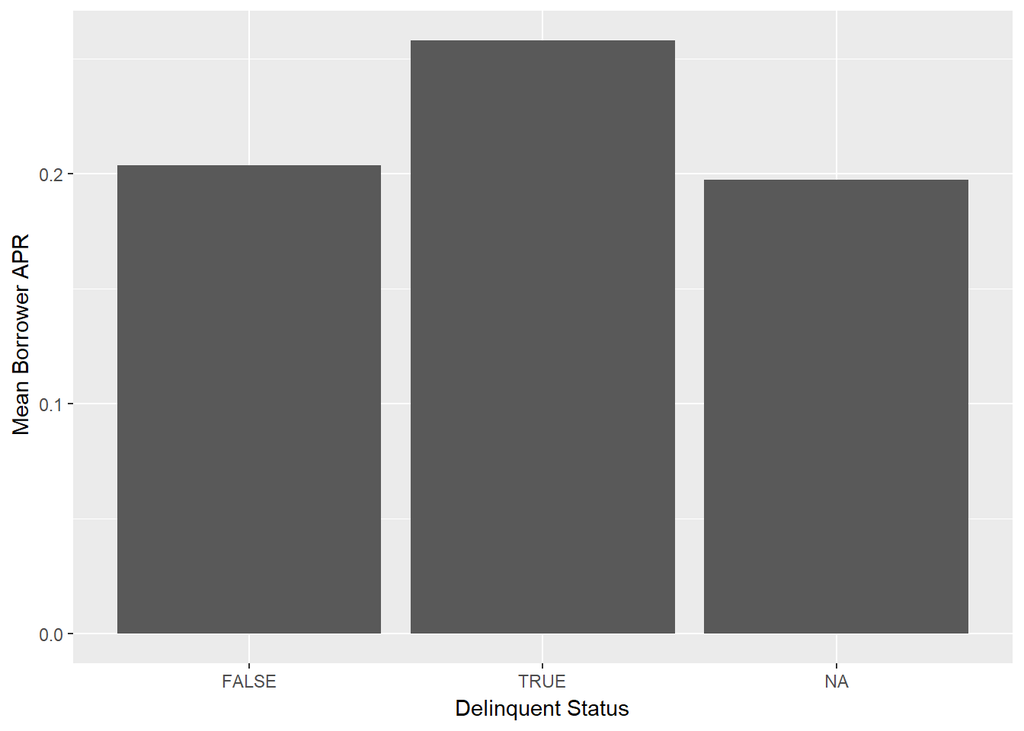

```r
ggplot(data = loans, aes(x= AmountDelinquent_BOOL, y=BorrowerAPR)) +
  geom_histogram(stat="summary", fun.y="median") +
  ylab(" Mean Borrower APR") + xlab ("Delinquent Status")
```

## Reflection Section

```r
m1 <- lm(loans$BorrowerAPR ~ loans$ListingCategory)
m2 <- update (m1, ~ . + loans$EmploymentStatusDuration)
m3 <- update (m2, ~ . + loans$IncomeRange)
m4 <- update (m3, ~ . + loans$ProsperScore)
m5 <- update (m4, ~ . + loans$AmountDelinquent)

mtable(m1,m2,m3,m4,m5)
```

```
##
## Calls:
## m1: lm(formula = loans$BorrowerAPR ~ loans$ListingCategory)
## m2: lm(formula = loans$BorrowerAPR ~ loans$ListingCategory + loans$EmploymentStatusDuration)
## m3: lm(formula = loans$BorrowerAPR ~ loans$ListingCategory + loans$EmploymentStatusDuration +
##     loans$IncomeRange)
## m4: lm(formula = loans$BorrowerAPR ~ loans$ListingCategory + loans$EmploymentStatusDuration +
##     loans$IncomeRange + loans$ProsperScore)
## m5: lm(formula = loans$BorrowerAPR ~ loans$ListingCategory + loans$EmploymentStatusDuration +
##     loans$IncomeRange + loans$ProsperScore + loans$AmountDelinquent)
##
## ===================================================================================================================================
##                                                          m1              m2              m3              m4              m5
## -----------------------------------------------------------------------------------------------------------------------------------
##   (Intercept)                                            0.211***        0.213***        0.167***        0.395***        0.395***
##                                                         (0.000)         (0.000)         (0.007)         (0.009)         (0.009)
##   loans$ListingCategory                                  0.003***        0.003***        0.002***        0.002***        0.002***
##                                                         (0.000)         (0.000)         (0.000)         (0.000)         (0.000)
##   loans$EmploymentStatusDuration                                        -0.000**         0.000***       -0.000***       -0.000***
##                                                                         (0.000)         (0.000)         (0.000)         (0.000)
##   loans$IncomeRange: $0/Not displayed                                                    0.036***
##                                                                                         (0.007)
##   loans$IncomeRange: Not employed/Not displayed                                          0.101***        0.010           0.010
##                                                                                         (0.007)         (0.009)         (0.009)
##   loans$IncomeRange: $1-24,999/Not displayed                                             0.071***       -0.019*         -0.019*
##                                                                                         (0.007)         (0.009)         (0.009)
##   loans$IncomeRange: $25,000-49,999/Not displayed                                        0.059***       -0.036***       -0.036***
##                                                                                         (0.007)         (0.009)         (0.009)
##   loans$IncomeRange: $50,000-74,999/Not displayed                                        0.041***       -0.046***       -0.047***
##                                                                                         (0.007)         (0.009)         (0.009)
##   loans$IncomeRange: $75,000-99,999/Not displayed                                        0.031***       -0.049***       -0.050***
##                                                                                         (0.007)         (0.009)         (0.009)
##   loans$IncomeRange: $100,000+/Not displayed                                             0.019**        -0.054***       -0.054***
##                                                                                         (0.007)         (0.009)         (0.009)
##   loans$ProsperScore                                                                                    -0.022***       -0.022***
##                                                                                                         (0.000)         (0.000)
##   loans$AmountDelinquent                                                                                                 0.000***
##                                                                                                                         (0.000)
## -----------------------------------------------------------------------------------------------------------------------------------
##   R-squared                                              0.018           0.016           0.057           0.473           0.474
##   adj. R-squared                                         0.018           0.016           0.057           0.473           0.474
##   sigma                                                  0.080           0.080           0.079           0.058           0.058
##   F                                                   2034.188         860.458         711.159        8467.230        7644.968
##   p                                                      0.000           0.000           0.000           0.000           0.000
##   Log-likelihood                                    126568.074      117317.766      119572.038      121171.592      121236.213
##   Deviance                                             722.774         684.857         656.420         285.402         284.968
##   AIC                                              -253130.148     -234627.531     -239122.076     -242321.184     -242448.427
##   BIC                                              -253101.218     -234589.235     -239016.761     -242218.351     -242336.245
##   N                                                 113912          106312          106312           84834           84834
## ===================================================================================================================================
```